# Linear Modeling

Gerko Vink

Statistical Programming with R

## We use the following packages

```r
library(MASS)
library(dplyr)
library(magrittr)
library(ggplot2)
library(mice)
library(DAAG)
library(car)
```

# Fitting a line to data

## Linear regression

Linear regression model
$$y_i=\alpha+\beta{x}_i+\varepsilon_i$$

Assumptions:

- $y_i$ conditionally normal with mean $\mu_i=\alpha+\beta{x}_i$
- $\varepsilon_i$ are $i.i.d.$ with mean 0 and (constant) variance $\sigma^2$

## The `anscombe` data

```r
head(anscombe)
```

```
##   x1 x2 x3 x4   y1   y2    y3   y4
## 1 10 10 10  8 8.04 9.14  7.46 6.58
## 2  8  8  8  8 6.95 8.14  6.77 5.76
## 3 13 13 13  8 7.58 8.74 12.74 7.71
## 4  9  9  9  8 8.81 8.77  7.11 8.84
## 5 11 11 11  8 8.33 9.26  7.81 8.47
## 6 14 14 14  8 9.96 8.10  8.84 7.04
```

Or, alternatively,

```r
anscombe %>%
  head
```

```
##   x1 x2 x3 x4   y1   y2    y3   y4
## 1 10 10 10  8 8.04 9.14  7.46 6.58
## 2  8  8  8  8 6.95 8.14  6.77 5.76
## 3 13 13 13  8 7.58 8.74 12.74 7.71
## 4  9  9  9  8 8.81 8.77  7.11 8.84
## 5 11 11 11  8 8.33 9.26  7.81 8.47
## 6 14 14 14  8 9.96 8.10  8.84 7.04
```

## Fitting a line

```r
anscombe %>%
  ggplot(aes(y1, x1)) +
  geom_point() +
  geom_smooth(method = "lm")
```

## Fitting a line

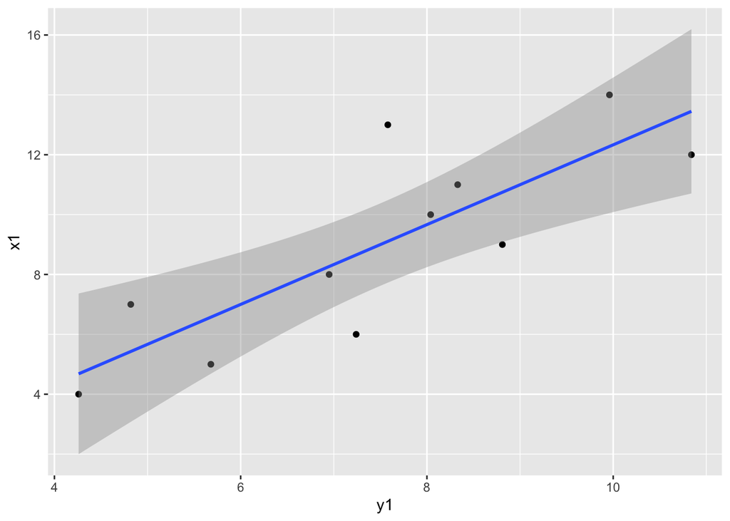

## Fitting a line

The linear model would take the following form:

```r
fit <-
  yourdata %>%
  lm(youroutcome ~ yourpredictors)

summary(fit)
```

Output:

- Residuals: minimum, maximum and quartiles
- Coefficients: estimates, SE’s, t-values and $p$-values
- Fit measures
  - Residuals SE (standard error residuals)
  - Multiple R-squared (proportion variance explained)
  - F-statistic and $p$-value (significance test model)

## `anscombe` example

```r
fit <- anscombe %$%
  lm(y1 ~ x1)

summary(fit)
```

```
##
## Call:
## lm(formula = y1 ~ x1)
##
## Residuals:
##      Min       1Q   Median       3Q      Max
## -1.92127 -0.45577 -0.04136  0.70941  1.83882
##
## Coefficients:
##             Estimate Std. Error t value Pr(>|t|)
## (Intercept)   3.0001     1.1247   2.667  0.02573 *
## x1            0.5001     0.1179   4.241  0.00217 **
## ---
## Signif. codes:  0 '***' 0.001 '**' 0.01 '*' 0.05 '.' 0.1 ' ' 1
##
## Residual standard error: 1.237 on 9 degrees of freedom
## Multiple R-squared:  0.6665, Adjusted R-squared:  0.6295
## F-statistic: 17.99 on 1 and 9 DF,  p-value: 0.00217
```

## Checking assumptions

1. linearity
   - scatterplot $y$ and $x$
   - include loess curve when in doubt
   - does a squared term improve fit?
2. normality residuals
   - normal probability plots `qqnorm()`
   - if sample is small; `qqnorm` with simulated errors cf. `rnorm(n, 0, s)`
3. constant error variance
   - residual plot
   - scale-location plot

## Linearity

```r
anscombe %>%
  ggplot(aes(x1, y1)) +
  geom_point() +
  geom_smooth(method = "loess", col = "blue") +
  geom_smooth(method = "lm", col = "orange")
```

## Linearity

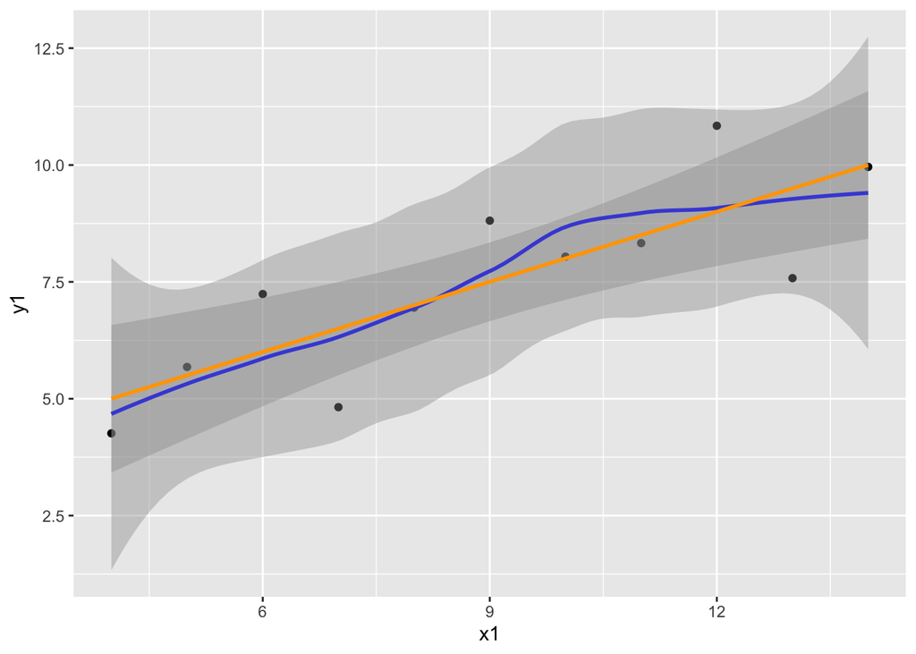

The loess curve suggests slight non-linearity

## Adding a squared term

```r
anscombe %$%
  lm(y1 ~ x1 + I(x1^2)) %>%
  summary()
```

```
##
## Call:
## lm(formula = y1 ~ x1 + I(x1^2))
##
## Residuals:
##     Min      1Q  Median      3Q     Max
## -1.8704 -0.3481 -0.2456  0.7129  1.8072
##
## Coefficients:
##             Estimate Std. Error t value Pr(>|t|)
## (Intercept)  0.75507    3.28815   0.230    0.824
## x1           1.06925    0.78982   1.354    0.213
## I(x1^2)     -0.03162    0.04336  -0.729    0.487
##
## Residual standard error: 1.27 on 8 degrees of freedom
## Multiple R-squared:  0.6873, Adjusted R-squared:  0.6092
## F-statistic: 8.793 on 2 and 8 DF,  p-value: 0.009558
```

## Constant error variance?

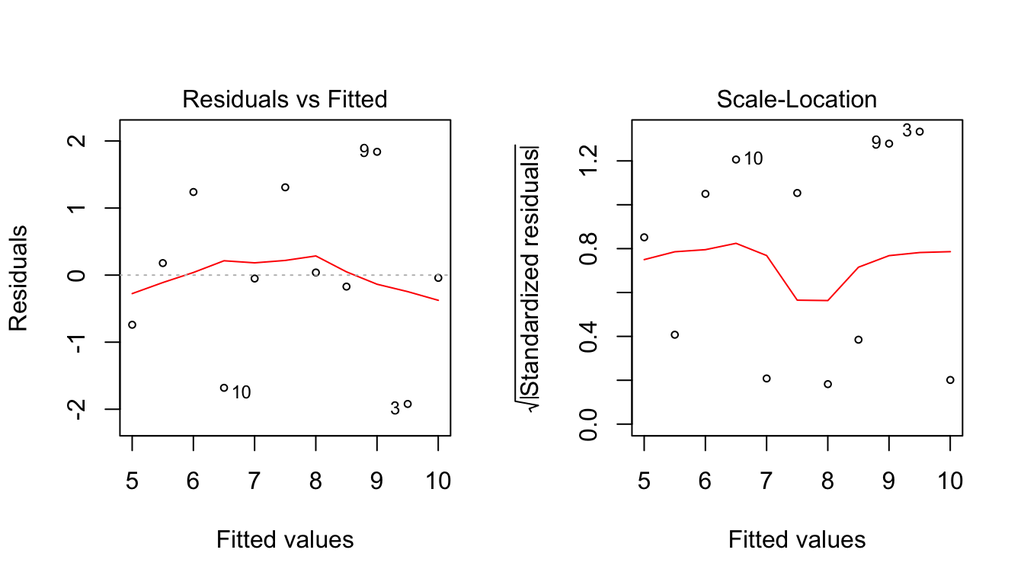

```r
par(mfrow = c(1, 2))
fit %>%
  plot(which = c(1, 3), cex = .6)
```

## No constant error variance!

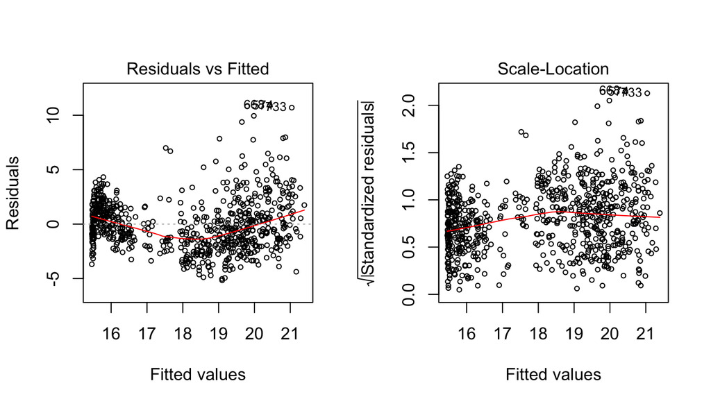

```r
par(mfrow = c(1, 2))
boys %$%
  lm(bmi ~ age) %>%
  plot(which = c(1, 3), cex = .6)
```

## Normality of errors

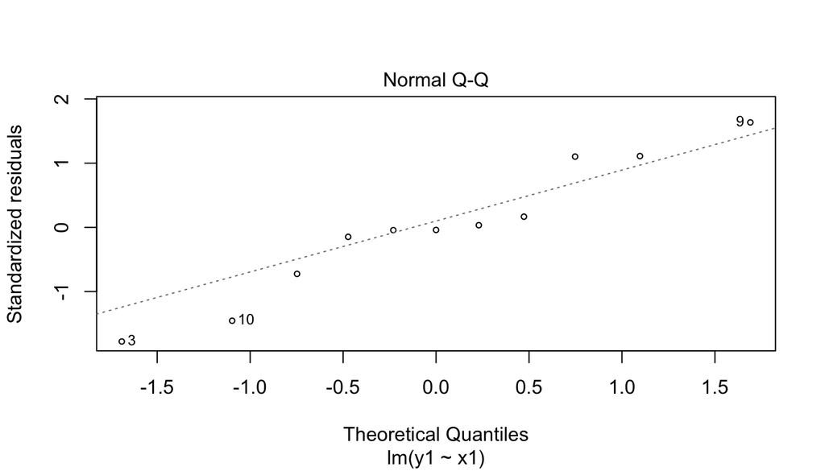

```r
fit %>%
  plot(which = 2, cex = .6)
```

The QQplot shows some divergence from normality at the tails

# Outliers, influence and robust regression

## Outliers and influential cases

Leverage: see the fit line as a lever.

- some points pull/push harder; they have more leverage

Standardized residuals:

- The values that have more leverage tend to be closer to the line
- The line is fit so as to be closer to them
- The residual standard deviation can differ at different points on $X$ - even if the error standard deviation is constant.
- Therefore we standardize the residuals so that they have constant variance (assuming homoscedasticity).

Cook’s distance: how far the predicted values would move if your model were fit without the data point in question.

- it is a function of the leverage and standardized residual associated with each data point

## Fine

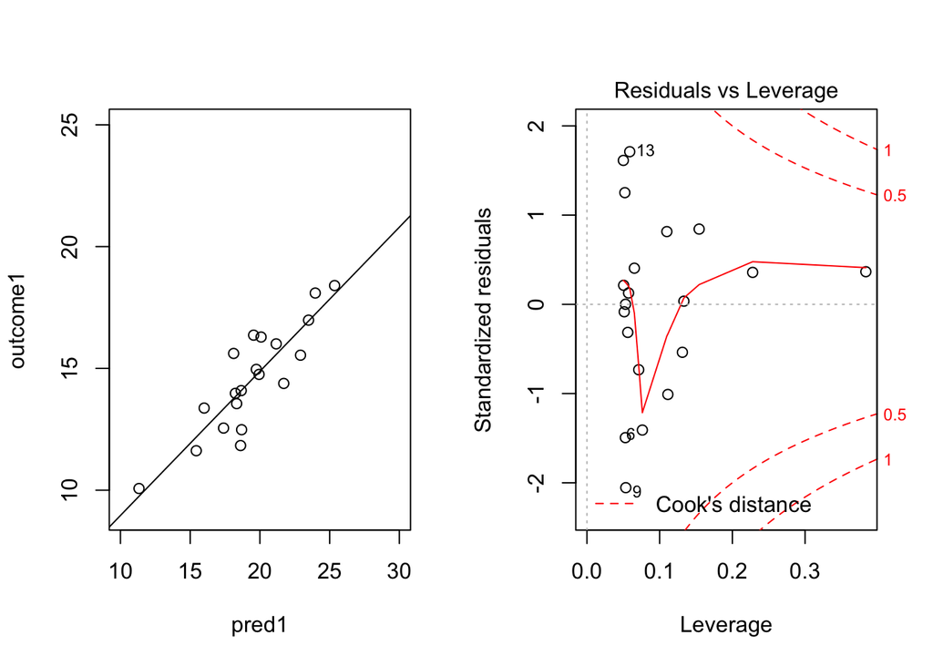

## High leverage, low residual

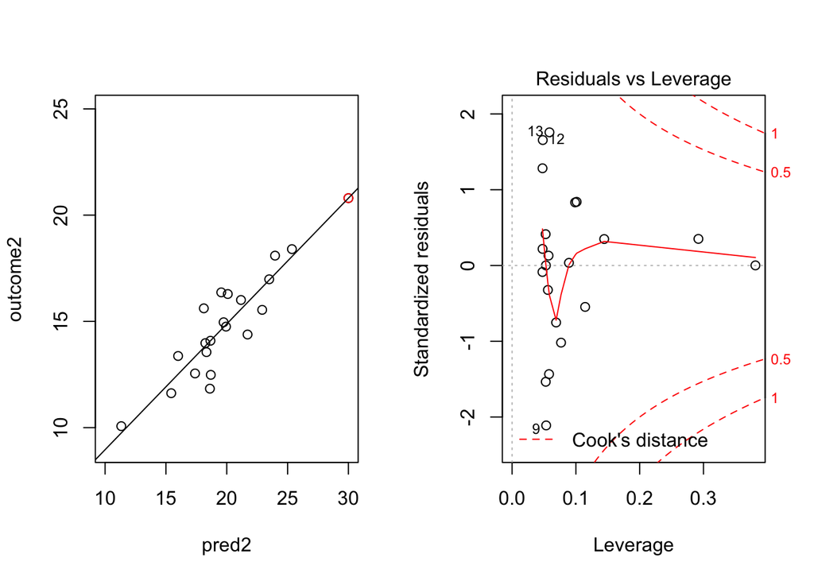

## Low leverage, high residual

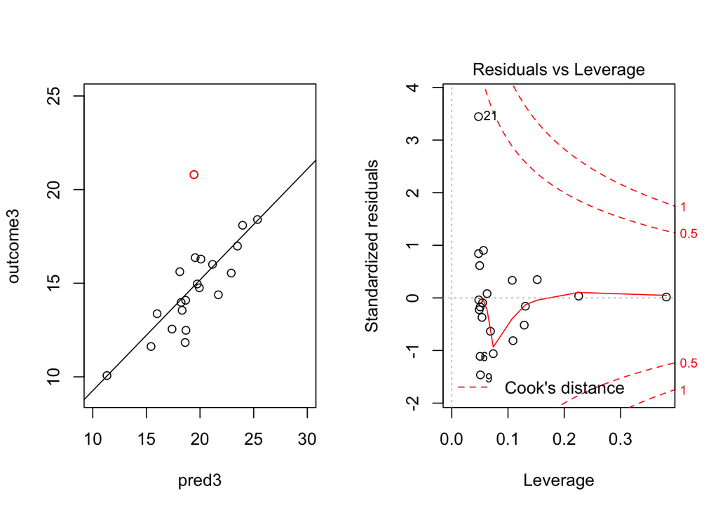

## High leverage, high residual

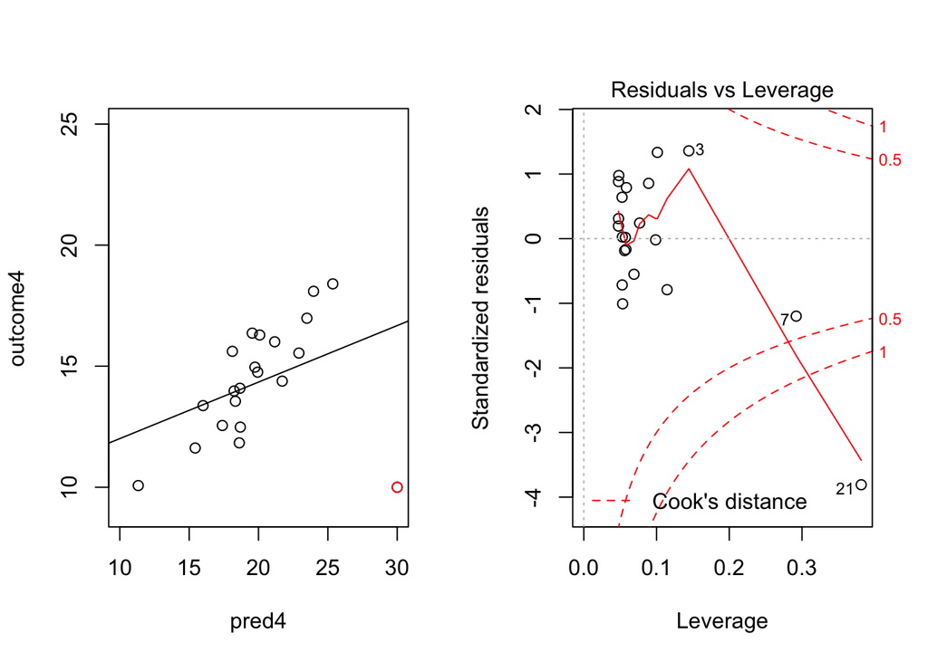

## Outliers and influential cases

Outliers are cases with large $e_z$ (standardized residuals).

If the model is *correct* we expect:

- 5% of $|e_z|>1.96$
- 1% of $|e_z|>2.58$
- 0% of $|e_z|>3.3$

Influential cases are cases with large influence on parameter estimates

- cases with Cook’s Distance $> 1$, or
- cases with Cook’s Distance much larger than the rest

## Outliers and influential cases

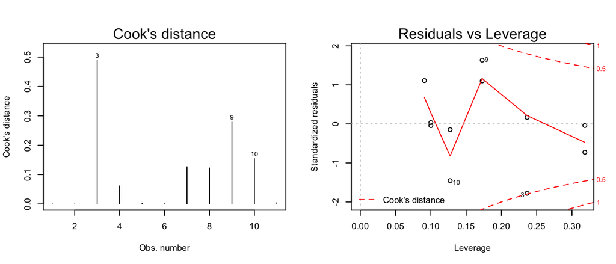

```r
par(mfrow = c(1, 2), cex = .6)
fit %>% plot(which = c(4, 5))
```

There are no cases with $|e_z|>2$, so no outliers (right plot). There are no cases with Cook’s Distance $>1$, but case 3 stands out

# Model fit

## New data example

```r
boys.fit <-
  na.omit(boys) %$% # Extremely wasteful
  lm(age ~ reg)
```

```r
boys %>%
  head
```

```
##      age  hgt   wgt   bmi   hc  gen  phb tv   reg
## 3  0.035 50.1 3.650 14.54 33.7 <NA> <NA> NA south
## 4  0.038 53.5 3.370 11.77 35.0 <NA> <NA> NA south
## 18 0.057 50.0 3.140 12.56 35.2 <NA> <NA> NA south
## 23 0.060 54.5 4.270 14.37 36.7 <NA> <NA> NA south
## 28 0.062 57.5 5.030 15.21 37.3 <NA> <NA> NA south
## 36 0.068 55.5 4.655 15.11 37.0 <NA> <NA> NA south
```

## Model

```r
boys.fit %>%
  anova()
```

```
## Analysis of Variance Table
##
## Response: age
##            Df Sum Sq Mean Sq F value Pr(>F)
## reg         4   14.7  3.6747  0.3701 0.8298
## Residuals 218 2164.6  9.9293
```

```r
boys.fit %>%
  summary()
```

```
##
## Call:
## lm(formula = age ~ reg)
##
## Residuals:
##     Min      1Q  Median      3Q     Max
## -5.8519 -2.5301  0.0254  2.2274  6.2614
##
## Coefficients:
##             Estimate Std. Error t value Pr(>|t|)
## (Intercept)  14.7109     0.5660  25.993   <2e-16 ***
## regeast      -0.8168     0.7150  -1.142    0.255
## regwest      -0.7044     0.6970  -1.011    0.313
## regsouth     -0.6913     0.6970  -0.992    0.322
## regcity      -0.6663     0.9038  -0.737    0.462
## ---
## Signif. codes:  0 '***' 0.001 '**' 0.01 '*' 0.05 '.' 0.1 ' ' 1
##
## Residual standard error: 3.151 on 218 degrees of freedom
## Multiple R-squared:  0.006745,   Adjusted R-squared:  -0.01148
## F-statistic: 0.3701 on 4 and 218 DF,  p-value: 0.8298
```

## Model factors

```r
boys.fit %>%
  model.matrix() %>%
  head()
```

```
##   (Intercept) regeast regwest regsouth regcity
## 1           1       0       0        0       0
## 2           1       0       0        1       0
## 3           1       0       0        1       0
## 4           1       1       0        0       0
## 5           1       0       1        0       0
## 6           1       1       0        0       0
```

## `aov()`

```r
boys.fit %>%
  aov()
```

```
## Call:
##    aov(formula = .)
##
## Terms:
##                       reg Residuals
## Sum of Squares    14.6987 2164.5869
## Deg. of Freedom         4       218
##
## Residual standard error: 3.151079
## Estimated effects may be unbalanced
```

`aov()` is for balanced designs.

## `anova()`

```r
boys.fit %>%
  anova()
```

```
## Analysis of Variance Table
##
## Response: age
##            Df Sum Sq Mean Sq F value Pr(>F)
## reg         4   14.7  3.6747  0.3701 0.8298
## Residuals 218 2164.6  9.9293
```

## `Anova()` with type I Sum of Squares

1. SS(A) for factor A.
2. SS(B | A) for factor B.
3. SS(AB | B, A) for interaction AB.
- If data are unbalanced, the ordering defines the estimates:
  - Different ordering of factors will yield different effects

## `Anova()` with type II Sum of Squares

1. SS(A | B) for factor A.
2. SS(B | A) for factor B.

No interaction assumed. So test for this first!

- only if interaction is not significant continue with interpretation of the main effects.
- most powerful if there is no interaction

## `Anova()` with type II Sum of Squares

```r
boys.fit %>%
  car::Anova(type = 2)
```

```
## Anova Table (Type II tests)
##
## Response: age
##           Sum Sq  Df F value Pr(>F)
## reg         14.7   4  0.3701 0.8298
## Residuals 2164.6 218
```

## `Anova()` with type III Sum of Squares

1. SS(A | B, AB) for factor A.
2. SS(B | A, AB) for factor B.

Tests if there is a main effect, given the other main effect and the interaction.

- however, most often we do not care about interpretation of the main effects if the interaction is significant

`When data are balanced, Type I, II and II are identical, because the factors are orthogonal`

## `Anova()` with type III Sum of Squares

```r
boys.fit %>%
  car::Anova(type = 3)
```

```
## Anova Table (Type III tests)
##
## Response: age
##             Sum Sq  Df  F value Pr(>F)
## (Intercept) 6708.8   1 675.6530 <2e-16 ***
## reg           14.7   4   0.3701 0.8298
## Residuals   2164.6 218
## ---
## Signif. codes:  0 '***' 0.001 '**' 0.01 '*' 0.05 '.' 0.1 ' ' 1
```

## Post hoc comparisons

```r
coef <-
  boys.fit %>%
  aov() %>%
  summary.lm()
coef
```

```
##
## Call:
## aov(formula = .)
##
## Residuals:
##     Min      1Q  Median      3Q     Max
## -5.8519 -2.5301  0.0254  2.2274  6.2614
##
## Coefficients:
##             Estimate Std. Error t value Pr(>|t|)
## (Intercept)  14.7109     0.5660  25.993   <2e-16 ***
## regeast      -0.8168     0.7150  -1.142    0.255
## regwest      -0.7044     0.6970  -1.011    0.313
## regsouth     -0.6913     0.6970  -0.992    0.322
## regcity      -0.6663     0.9038  -0.737    0.462
## ---
## Signif. codes:  0 '***' 0.001 '**' 0.01 '*' 0.05 '.' 0.1 ' ' 1
##
## Residual standard error: 3.151 on 218 degrees of freedom
## Multiple R-squared:  0.006745,   Adjusted R-squared:  -0.01148
## F-statistic: 0.3701 on 4 and 218 DF,  p-value: 0.8298
```

## Post hoc comparisons

```r
p.val <- coef$coefficients
p.adjust(p.val[, "Pr(>|t|)"], method = "bonferroni")
```

```
##  (Intercept)      regeast      regwest     regsouth      regcity
## 5.077098e-68 1.000000e+00 1.000000e+00 1.000000e+00 1.000000e+00
```

## AIC and BIC

Akaike’s *An Information Criterion*

```r
boys.fit %>%
  AIC()
```

```
## [1] 1151.684
```

and *Bayesian Information Criterion*

```r
boys.fit %>%
  BIC()
```

```
## [1] 1172.127
```

## Model comparison

```r
boys.fit2 <-
  na.omit(boys) %$%
  lm(age ~ reg + hgt)

boys.fit %>% AIC()
```

```
## [1] 1151.684
```

```r
boys.fit2 %>% AIC()
```

```
## [1] 836.3545
```

## Another model

```r
boys.fit3 <-
  na.omit(boys) %$%
  lm(age ~ reg + hgt * wgt)
```

is equivalent to

```r
boys.fit3 <-
  na.omit(boys) %$%
  lm(age ~ reg + hgt + wgt + hgt:wgt)
```

## Model comparison

```r
boys.fit %>% AIC()
```

```
## [1] 1151.684
```

```r
boys.fit2 %>% AIC()
```

```
## [1] 836.3545
```

```r
boys.fit3 %>% AIC()
```

```
## [1] 823.0386
```

## Model comparison

```r
anova(boys.fit, boys.fit2, boys.fit3)
```

```
## Analysis of Variance Table
##
## Model 1: age ~ reg
## Model 2: age ~ reg + hgt
## Model 3: age ~ reg + hgt * wgt
##   Res.Df     RSS Df Sum of Sq      F    Pr(>F)
## 1    218 2164.59
## 2    217  521.64  1   1642.94 731.83 < 2.2e-16 ***
## 3    215  482.67  2     38.97   8.68  0.000237 ***
## ---
## Signif. codes:  0 '***' 0.001 '**' 0.01 '*' 0.05 '.' 0.1 ' ' 1
```

## Model fit again

```r
boys.fit3 %>%
  car::Anova(type = 3)
```

```
## Anova Table (Type III tests)
##
## Response: age
##             Sum Sq  Df F value   Pr(>F)
## (Intercept)  27.04   1 12.0434 0.000628 ***
## reg           5.90   4  0.6569 0.622651
## hgt         106.79   1 47.5667 5.84e-11 ***
## wgt           7.33   1  3.2654 0.072152 .
## hgt:wgt       2.99   1  1.3324 0.249655
## Residuals   482.67 215
## ---
## Signif. codes:  0 '***' 0.001 '**' 0.01 '*' 0.05 '.' 0.1 ' ' 1
```

## Model fit again

```r
boys.fit3 %>%
  car::Anova(type = 2)
```

```
## Anova Table (Type II tests)
##
## Response: age
##           Sum Sq  Df F value    Pr(>F)
## reg         5.90   4  0.6569    0.6227
## hgt       170.35   1 75.8810 8.114e-16 ***
## wgt        35.98   1 16.0276 8.595e-05 ***
## hgt:wgt     2.99   1  1.3324    0.2497
## Residuals 482.67 215
## ---
## Signif. codes:  0 '***' 0.001 '**' 0.01 '*' 0.05 '.' 0.1 ' ' 1
```

## Model fit again

```r
boys.fit3 %>%
  anova()
```

```
## Analysis of Variance Table
##
## Response: age
##            Df  Sum Sq Mean Sq  F value    Pr(>F)
## reg         4   14.70    3.67   1.6368    0.1661
## hgt         1 1642.94 1642.94 731.8311 < 2.2e-16 ***
## wgt         1   35.98   35.98  16.0276 8.595e-05 ***
## hgt:wgt     1    2.99    2.99   1.3324    0.2497
## Residuals 215  482.67    2.24
## ---
## Signif. codes:  0 '***' 0.001 '**' 0.01 '*' 0.05 '.' 0.1 ' ' 1
```

## Influence of cases

DfBeta calculates the change in coefficients depicted as deviation in SE’s.

```r
boys.fit3 %>%
  dfbeta() %>%
  head(n = 7)
```

```
##   (Intercept)      regeast       regwest      regsouth       regcity
## 1  0.30446529 -0.032645200 -0.0326165198 -0.0304499108 -0.0318295197
## 2 -0.12357958  0.003358160  0.0031894645 -0.0355420008  0.0050565041
## 3 -0.17522651  0.001479115  0.0015118575 -0.0134428270  0.0001493751
## 4 -0.08857830 -0.006195476  0.0007649256  0.0002461411 -0.0001545015
## 5  0.31715776  0.003385884 -0.0572382687  0.0032145390  0.0142911153
## 6 -0.17554676 -0.018945547  0.0024334472  0.0015126731  0.0006986407
## 7 -0.08200772  0.013753533  0.0137667118  0.0134385305  0.0131184131
##             hgt          wgt       hgt:wgt
## 1 -0.0018391896 -0.001790011  1.389532e-05
## 2  0.0009885098 -0.002377479  9.303061e-06
## 3  0.0010352437  0.002803606 -1.608245e-05
## 4  0.0004883509  0.001847202 -1.001945e-05
## 5 -0.0009320126 -0.019683940  9.719343e-05
## 6  0.0009077265  0.003892513 -2.022645e-05
## 7  0.0003391486  0.001610804 -8.082354e-06
```

# Prediction

## Fitted values:

Let’s use the simpler `anscombe` data example

```r
y_hat <-
  fit %>%
  fitted.values()
```

The residual is then calculated as

```r
y_hat - anscombe$y1
```

```
##           1           2           3           4           5           6
## -0.03900000  0.05081818  1.92127273 -1.30909091  0.17109091  0.04136364
##           7           8           9          10          11
## -1.23936364  0.74045455 -1.83881818  1.68072727 -0.17945455
```

## Predict new values

If we introduce new values for the predictor `x1`, we can generate predicted values from the model

```r
new.x1 <- data.frame(x1 = 1:20)
predict.lm(fit, newdata = new.x1)
```

```
##         1         2         3         4         5         6         7
##  3.500182  4.000273  4.500364  5.000455  5.500545  6.000636  6.500727
##         8         9        10        11        12        13        14
##  7.000818  7.500909  8.001000  8.501091  9.001182  9.501273 10.001364
##        15        16        17        18        19        20
## 10.501455 11.001545 11.501636 12.001727 12.501818 13.001909
```

## Predictions are draws from the regression line

```r
pred <- predict.lm(fit, newdata = new.x1)
lm(pred ~ new.x1$x1)$coefficients
```

```
## (Intercept)   new.x1$x1
##   3.0000909   0.5000909
```

```r
fit$coefficients
```

```
## (Intercept)          x1
##   3.0000909   0.5000909
```

## Prediction intervals

```r
predict(fit, interval = "prediction")
```

```
##          fit      lwr       upr
## 1   8.001000 5.067072 10.934928
## 2   7.000818 4.066890  9.934747
## 3   9.501273 6.390801 12.611745
## 4   7.500909 4.579129 10.422689
## 5   8.501091 5.531014 11.471168
## 6  10.001364 6.789620 13.213107
## 7   6.000636 2.971271  9.030002
## 8   5.000455 1.788711  8.212198
## 9   9.001182 5.971816 12.030547
## 10  6.500727 3.530650  9.470804
## 11  5.500545 2.390073  8.611017
```

# Assessing predictive accuracy

## K-fold cross-validation

- Divide sample in $k$ mutually exclusive training sets
- Do for all $j\in\{1,\dots,k\}$ training sets
  1. fit model to training set $j$
  2. obtain predictions for test set $j$ (remaining cases)
  3. compute residual variance (MSE) for test set $j$
- Compare MSE in cross-validation with MSE in sample
- Small difference suggests good predictive accuracy

## K-fold cross-validation `anscombe` data

- residual variance sample is $1.24^2 \approx 1.53$
- residual variance cross-validation is 1.93
- regression lines in the 3 folds are similar

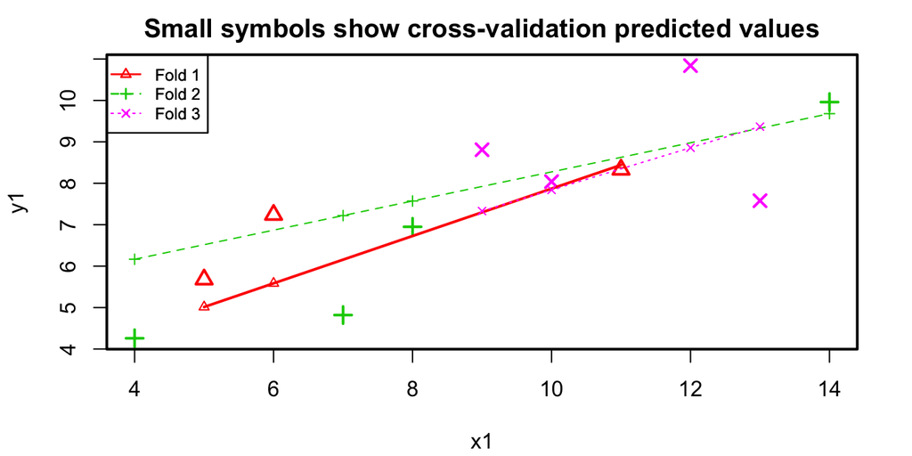

```r
DAAG::CVlm(anscombe, fit, plotit=T, printit=F)
```

## K-fold cross-validation `boys` data

- residual variance sample is 2
- residual variance cross-validation is 2.38
- regression lines in the 3 folds almost identical

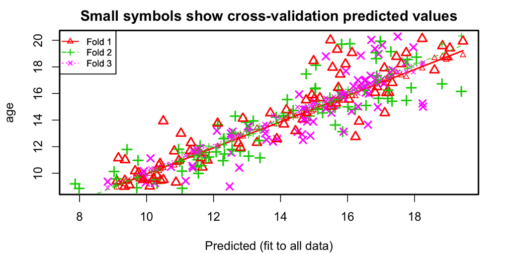

```r
DAAG::CVlm(na.omit(boys), boys.fit3, plotit=T, printit=F)
```

## How many cases are used?

```r
na.omit(boys) %$%
  lm(age ~ reg + hgt * wgt) %>%
  nobs()
```

```
## [1] 223
```

If we would not have used `na.omit()`

```r
boys %$%
  lm(age ~ reg + hgt * wgt) %>%
  nobs()
```

```
## [1] 724
```

## Some other modeling devices in `R`

- `lm()`: linear modeling
- `glm()`: generalized linear modeling
- `gamlss::gamlss`: generalized additive models (for location, scale and shape)
- `lme4::lmer`: linear mixed effect models
- `lme4::glmer`: generalized linear mixed effect models
- `lme4::nlmer`: non-linear mixed effect models